# CSE 5243 - Introduction to Data Mining

## Homework 4: Clustering

- Semester: Fall 2024
- Instructor: John Paparrizos
- Section: Tuesday/Thursday 11:10 AM
- Student Name: Khushboo Suchit Mundada
- Student.#: mundada.10

**Instructions and Helpful Hints:**

- Consider putting all of your "discussion" text in markdown cells, not inline with code. That gives you more control over formatting. Markdown cheat sheet: https://www.markdownguide.org/cheat-sheet
- Explain what you are doing, and why. Explain what you found out or learned.
- *Make sure you run your entire workbook before handing it in, so the output cells are populated.*
- Follow the Section structure as much as possible - put your content where it is requested, so we can find your answers.
- If you have questions on expectations or need clarification or guidance, please ask. Post to Teams if it is a general question, so everyone benefits.

# Introduction

### Objectives:

In this lab, you will perform clustering on three datasets. Your will choose suitable clustering algorithms, evaluate them on the datasets, and compare their performance.

The objectives of this assignment are:

1. Understand how to select and evaluate suitable off-the-shelf clustering algorithms based on the characteristics of a dataset and the outcomes you need.
2. Understand how to tune and evaluate a clustering algorithm to achieve good performance.

### Datasets:

- The file **small_Xydf.csv** is a two-dimensional dataset with 200 records. It contains columns X0, X1, and y. The y column is the actual cluster number that was produced by the dataset generation algorithm. Do not use it for the clustering algorithm. It will be used to evaluate your clustering algorithm below.
- The file **large1_Xydf.csv** is a two-dimensional dataset with 3000 records. It contains columns X0, X1, and y. The y column is the actual cluster number that was produced by the dataset generation algorithm. Do not use it for the clustering algorithm. It will be used to evaluate your clustering algorithm below.
- The file **large2_Xydf.csv** is another two-dimensional dataset with 3000 records, and characteristics different from the “large1” dataset. It contains columns X0, X1, and y. The y column is the actual cluster number that was produced by the dataset generation algorithm. Do not use it for the clustering algorithm. It will be used to evaluate your clustering algorithm below.

### Approach:

This homework makes use of the Clustering Algorithms offered by the SciKitLearn Library. Study the information at https://scikit-learn.org/stable/modules/clustering.html. Follow the guidance in the individual sections below.

### Collaboration:

For this assignment, you should work as an individual. You may informally discuss ideas with classmates, to get advice on general Python usage, etc., but your work should be your own. Please make use of Microsoft Teams!

### What you need to turn in:

1. Code
- For this homework, the code is the Jupyter Notebook. Use the provided Jupyter Notebook template, and fill in the appropriate information.
- This homework requires you to use clustering algorithms in the SciKitLearn library. You also may use common Python libraries for I/O, data manipulation, data visualization, etc. (e.g., NumPy, Pandas, MatPlotLib,…). You may not use library operations that perform, in effect, the entire “core” computations for this homework. (e.g., If you happen to find a single function on the web that does essentially *all* of a major portion of the homework, you may not use it.) When in doubt, ask the grader or instructor.
- The code must be written by you, and any significant code snips you found on the Internet and used to understand how to do your coding for the core functionality must be attributed. (You do not need to attribute basic functionality – matrix operations, IO, etc.)
- The code must be commented sufficiently to allow a reader to understand the algorithm without reading the actual Python, step by step.
- When in doubt, ask the grader or instructor.
1. Written Report
- For this homework, the report is the Jupyter Notebook. The report should be well-written. Please proof-read and remove spelling and grammar errors and typos. Please also include the HTML file, which helps the grading process.
- The report should discuss your analysis and observations. Key points and findings must be written in a style suitable for consumption by non-experts. Present charts and graphs to support your observations. If you performed any data processing, cleaning, etc., please discuss it within the report.

### Grading:

1. Overall readability and organization of your report (10%) - Is it well organized and does the presentation flow in a logical manner; are there many grammar and spelling mistakes; do the charts/graphs relate to the text, etc.
2. Evaluation of the K-means Clustering Algorithm on the Small Dataset (15%) – Is your configuration sound? Have you made an effort to tune the algorithm for good performance? Are your analyses and evaluations sound, and supported by suitable statistics and/or visualizations?
3. Evaluation of the K-means Clustering Algorithm on the Large1 Dataset (15%) – Is your configuration sound? Have you made an effort to tune the algorithm for good performance? Are your analyses and evaluations sound, and supported by suitable statistics and/or visualizations?
4. Evaluation of the K-means Clustering Algorithm on the Large2 Dataset (15%) – Is your configuration sound? Have you made an effort to tune the algorithm for good performance? Are your analyses and evaluations sound, and supported by suitable statistics and/or visualizations?
5. Evaluation of the Second Clustering Algorithm on the Large2 Dataset (15%) – Is your choice of algorithm and your configuration sound? Have you made an effort to tune the algorithm for good performance? Are your analyses and evaluations sound, and supported by suitable statistics and/or visualizations?
6. Evaluation of the Third Clustering Algorithm on the Large2 Dataset (15%) – Is your choice of algorithm and your configuration sound? Have you made an effort to tune the algorithm for good performance? Are your analyses and evaluations sound, and supported by suitable statistics and/or visualizations?
7. Comparison of the Three Clustering Algorithms (10%) - Is the comparison sound? Did you choose a specific clustering algorithm as best and explain why?
8. Conclusions (5%) – Did you document your overall insights?

### How to turn in your work on Carmen:

**Please follow these instructions exactly** - it helps the grading process. If you have questions, please ask. Submit to Carmen any code that you used to process and analyze this data. You do not need to include the input data. All the related files (code and report) except for the data should be archived in a **zip file (with no folder trees inside)** and submitted via Carmen. The submitted file should be less than 5MB. Use this naming convention: **HomeworkN_Surname_DotNumber.zip**

### References and Acknowledgements:

1. https://scikit-learn.org/stable/modules/classes.html#module-sklearn.cluster
2. https://scikit-learn.org/stable/modules/clustering.html
3. https://docs.python.org/3/library/time.html
4. https://docs.scipy.org/doc/scipy/reference/generated/scipy.optimize.linear_sum_assignment.html
5. https://gist.github.com/siolag161/dc6e42b64e1bde1f263b (using Hungarian Algorithm to match cluster labels - this is just an example)
6. https://scikit-learn.org/stable/modules/generated/sklearn.metrics.mean_squared_error.html (note that this is **mean** squared error)

# Section: Overview

- Insert a short description of the scope of this exercise, any supporting information, etc.

In this exercise, I will explore the application of clustering algorithms on three distinct datasets. The scope includes selecting appropriate clustering techniques, implementing them, and evaluating their performance based on dataset characteristics. I will gain hands-on experience with clustering using the SciKitLearn library and learn how to fine-tune algorithms to achieve optimal results. The datasets provided vary in size and structure, offering a comprehensive opportunity to assess the adaptability and effectiveness of different clustering approaches.

# Section: Setup

- Add any needed imports, helper functions, etc., here.

```python
# Importing necessary libraries for data manipulation, clustering, evaluation, and visualization

import numpy as np
import pandas as pd
import matplotlib.pyplot as plt
import seaborn as sns
from sklearn.cluster import KMeans, DBSCAN, AgglomerativeClustering
from sklearn.metrics import silhouette_score, adjusted_rand_score, homogeneity_score, classification_report, confusion_matrix
from scipy.optimize import linear_sum_assignment
import scipy.cluster.hierarchy as sch
import time
from sklearn.preprocessing import StandardScaler
```

This function uses the Hungarian algorithm (through linear_sum_assignment) to optimally match predicted labels to true labels by maximizing the number of matched points. It builds a cost matrix where each cell represents how many points are correctly classified between a true and predicted label. The function then returns the matched predicted labels based on the optimal assignment of clusters.

```python
# Function to match predicted and true labels using Hungarian algorithm
def match_labels(true_labels, predicted_labels, n_clusters):
    # Create a cost matrix with size (n_clusters x n_clusters)
    cost_matrix = np.zeros((n_clusters, n_clusters))

    # Populate the cost matrix with the number of matching points between true and predicted labels
    for i in range(n_clusters):
        for j in range(n_clusters):
            # Count the number of points that belong to both cluster 'i' (true) and cluster 'j' (predicted)
            cost_matrix[i, j] = np.sum((true_labels == i) & (predicted_labels == j))

    # Use the Hungarian algorithm (linear sum assignment) to find the optimal label matching
    row_ind, col_ind = linear_sum_assignment(cost_matrix, maximize=True)

    # Apply the optimal label matching to the predicted labels
    matched_labels = np.array([col_ind[label] for label in predicted_labels])

    return matched_labels
```

It computes the Within-cluster Sum of Squares (WSS), Between-cluster Sum of Squares (BSS), and Total SSE to evaluate clustering performance. WSS measures how tightly data points are grouped within each cluster, BSS quantifies the separation between clusters, and Total SSE is the sum of WSS and BSS, representing overall clustering quality.

```python
def calculate_true_clusters(X, true_labels):
    # Get the unique labels of the clusters
    unique_labels = np.unique(true_labels)

    # Get the total number of data points
    n = X.shape[0]

    # Calculate the overall mean of the dataset
    total_mean = np.mean(X, axis=0)

    # Initialize WSS and BSS to zero
    WSS = 0
    BSS = 0

    # Loop through each cluster label
    for label in unique_labels:
        # Get the points that belong to the current cluster
        cluster_points = X[true_labels == label]

        # Calculate the mean of the current cluster
        cluster_mean = np.mean(cluster_points, axis=0)

        # Compute WSS: Sum of squared distances between each point and the cluster's mean
        WSS += np.sum(np.linalg.norm(cluster_points - cluster_mean, axis=1) ** 2)

        # Compute BSS: Sum of squared distances between the cluster's mean and the overall mean,
        # weighted by the number of points in the cluster
        BSS += len(cluster_points) * np.linalg.norm(cluster_mean - total_mean) ** 2

    # Total SSE is the sum of WSS and BSS
    total_SSE = WSS + BSS
    return WSS, BSS, total_SSE
```

I have used this same kmeans_clustering function for each run of the K-means clustering with different values of K (the number of clusters). For each configuration of K, the function calculates the WSS, BSS, and total SSE values, and also tracks the execution time of the K-means algorithm. The function is reused across multiple values of K to maintain consistency and streamline the process of clustering evaluation.

**Paramaters** -  
n_clusters=K: Sets the number of clusters. Chose K to match the number of true classes in your data.  
init='k-means++': Picks better initial centroids, leading to faster and more accurate results. (default)  
max_iter=300: Limits the number of iterations to 300, enough for most cases to ensure convergence. (default)  
random_state=42: Ensures results are the same each run, making comparisons consistent and reproducible.

```python
# Function to perform K-means clustering and calculate WSS, BSS, and total SSE
def kmeans_clustering(X, K):
    # Start the timer to calculate execution time
    start_time = time.time()

    # Initialize KMeans with specified parameters and fit the model to the data
    kmeans = KMeans(n_clusters=K, init='k-means++', max_iter=300, random_state=42)
    kmeans.fit(X)

    # Get the predicted labels after fitting the model
    predicted_labels = kmeans.labels_

    # Calculate WSS, BSS, and total SSE using the true clustering method
    WSS, BSS, total_SSE = calculate_true_clusters(X, predicted_labels)

    # End the timer and calculate the total execution time
    end_time = time.time()
    execution_time = end_time - start_time

    # Return the calculated metrics and execution time
    return WSS, BSS, total_SSE, execution_time
```

# Section: 1 - Evaluate the **K-Means** Algorithm on the **Small** Dataset

## Section: 1.1 - Calculate True Cluster Measures

- Given that you know the true clusters (from column y in the original data), compute the true within-cluster WSS (also called “SSE” in the slides), the between-cluster BSS, and the Total SSE (WSS+BSS).

```python
# Load the dataset
data = pd.read_csv('small_Xydf.csv')
X = data[['X0', 'X1']].values
true_labels = data['y'].values

WSS, BSS, total_SSE = calculate_true_clusters(X, true_labels)
print(f"True WSS: {round(WSS, 4)}\nTrue BSS: {round(BSS, 4)}\nTotal SSE: {round(total_SSE, 4)}")
```

```
True WSS: 1506.5322
True BSS: 7652.2829
Total SSE: 9158.8151
```

## Section: 1.2 - Configure and Run the SciKitLearn K-Means Algorithm

- Explain all configuration parameter values you chose, and why you chose them.
- Run your algorithm for K=2, 3, 4.
- For each run, compute the WSS, BSS, and Total SSE (WSS+BSS), and compute the running time (see Python Time reference – see %%time, time.process_time(), etc.).

```python
# Run K-means for K=2, 3, 4
results = {}
for K in [2, 3, 4]:
    WSS, BSS, total_SSE, execution_time = kmeans_clustering(X, K)
    results[K] = {'WSS': round(WSS, 4), 'BSS': round(BSS, 4), 'Total SSE': round(total_SSE, 4), 'Execution Time': round(execution_time, 4)}

for key, value in results.items():
    print("For K value =", key, ":", value)
```

```
For K value = 2 : {'WSS': 2222.185, 'BSS': 6936.6301, 'Total SSE': 9158.8151, 'Execution Time': 0.027}
For K value = 3 : {'WSS': 1368.7518, 'BSS': 7790.0632, 'Total SSE': 9158.8151, 'Execution Time': 0.041}
For K value = 4 : {'WSS': 1157.5678, 'BSS': 8001.2472, 'Total SSE': 9158.8151, 'Execution Time': 0.057}
```

## Section: 1.3 - For the K=3 Case Above:

- Create a scatterplot, overlaying the true cluster with the cluster produced by your algorithm. (Or alternatively, create two side by side scatterplots).
- Create a cross tabulation matrix (i.e., confusion matrix) comparing the true and assigned clusters, and the basic measures (precision, recall, F1, accuracy, etc. - see classification_report). Note that you may need to "match up" the true and assigned cluster labels. See the linear-sum-assignment and Hungarian algorithm references, for example.

```python
# Get predicted labels for K=3
K = 3
kmeans = KMeans(n_clusters=K, init='k-means++', max_iter=300, random_state=42)
kmeans.fit(X)
predicted_labels = kmeans.labels_

# Match predicted labels to true labels
matched_labels = match_labels(true_labels, predicted_labels, K)
```

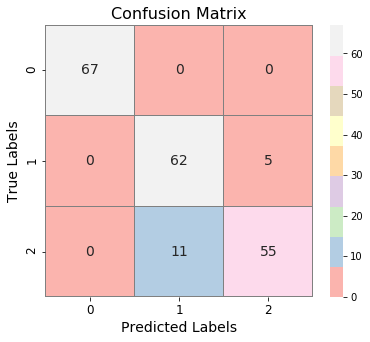

```python
# Confusion matrix
cm = confusion_matrix(true_labels, matched_labels)

# Create the heatmap
plt.figure(figsize=(6, 5))
sns.heatmap(
    cm,
    annot=True,
    fmt='d',
    cmap='Pastel1',
    linewidths=0.3,
    linecolor='gray',
    annot_kws={"size": 14}
)
plt.title('Confusion Matrix', fontsize=16)
plt.xlabel('Predicted Labels', fontsize=14)
plt.ylabel('True Labels', fontsize=14)
plt.xticks(fontsize=12)
plt.yticks(fontsize=12)
plt.show()
```

```python
# Classification report
report = classification_report(true_labels, matched_labels, output_dict=True)

report_df = pd.DataFrame(report).transpose()

# Display the report
print("Classification Report:")
report_df
```

```
Classification Report:
```

|  | precision | recall | f1-score | support |
| --- | --- | --- | --- | --- |
| 0 | 1.000000 | 1.000000 | 1.000000 | 67.00 |
| 1 | 0.849315 | 0.925373 | 0.885714 | 67.00 |
| 2 | 0.916667 | 0.833333 | 0.873016 | 66.00 |
| accuracy | 0.920000 | 0.920000 | 0.920000 | 0.92 |
| macro avg | 0.921994 | 0.919569 | 0.919577 | 200.00 |
| weighted avg | 0.922021 | 0.920000 | 0.919810 | 200.00 |

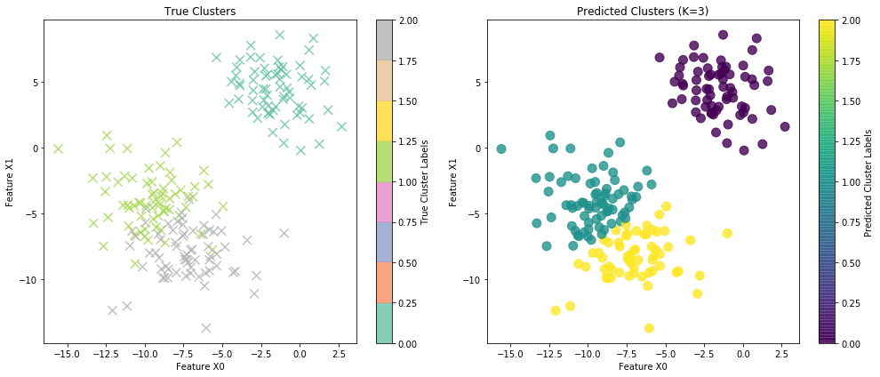

```python
# Enhanced side-by-side scatter plot with better visuals
plt.figure(figsize=(14, 6))

# Plot for true clusters
plt.subplot(1, 2, 1)
scatter_true = plt.scatter(X[:, 0], X[:, 1], c=true_labels, cmap='Set2', marker='x', alpha=0.8, s=100)
plt.title('True Clusters')
plt.xlabel('Feature X0')
plt.ylabel('Feature X1')
plt.colorbar(scatter_true, label='True Cluster Labels')

# Plot for predicted clusters
plt.subplot(1, 2, 2)
scatter_pred = plt.scatter(X[:, 0], X[:, 1], c=matched_labels, cmap='viridis', marker='o', alpha=0.8, s=100)
plt.title('Predicted Clusters (K=3)')
plt.xlabel('Feature X0')
plt.ylabel('Feature X1')
plt.colorbar(scatter_pred, label='Predicted Cluster Labels')

plt.tight_layout()
plt.show()
```